# Factor_Analysis

2023-03-03

Question 1. Decide how many Factors are ideal for your dataset ANS: In this question, two factors are ideal for the dataset. That is because from the scree plot there are significant decrease of the line before the factor is 2. After factor = 2, the change of the line is not significant. And after factor = 2, the data point is under the eigenvalue line. Additionally, from the chart of Very Simple Structure, factor = 2 line has good performance in fit.

Question 2. Explain the output for your factor model ANS: In component analysis, the factor loading between PC1 and area, rooms, bathroom, fire insurance, parking spaces are 0.9, 0.9, 0.8, 0.8, 0.8. The factor loading between PC2 and property tax, hoa are 0.9, 0.8.

Question 3. Show the columns that go into each factor ANS: The columns of each factors are as follows. Click to factors columns

Question 4. Perform some visualizations using the factors ANS: Here is the plot of variance of PCA factors (click). The plot of component analysis (click) is also a kind of visualization of factors and variables.

```r
# Factor Analysis
library(psych)
library(readr)
house_data <- read_csv("Dataset/Rent_House_random_200.csv")
house_data <- house_data[, c(1:4, 6:11)]
house_vars <- house_data[,-c(5,6,8)]
str(house_vars)
```

```
## tibble [200 × 7] (S3: tbl_df/tbl/data.frame)
##  $ area          : num [1:200] 120 45 50 35 204 177 15 70 180 180 ...
##  $ rooms         : num [1:200] 3 1 2 1 4 3 1 2 3 4 ...
##  $ bathroom      : num [1:200] 4 1 1 1 4 3 1 2 3 4 ...
##  $ parking spaces: num [1:200] 3 1 1 0 2 4 0 1 2 2 ...
##  $ hoa           : num [1:200] 1350 3000 226 260 0 2700 0 1800 700 2600 ...
##  $ property tax  : num [1:200] 560 0 0 0 100 509 0 250 175 584 ...
##  $ fire insurance: num [1:200] 71 70 10 18 62 89 16 55 40 26 ...
```

```r
#house_data[-1]
```

```r
fit.pc <- principal(house_vars, nfactors=4, rotate="varimax")
fit.pc
```

```
## Principal Components Analysis
## Call: principal(r = house_vars, nfactors = 4, rotate = "varimax")
## Standardized loadings (pattern matrix) based upon correlation matrix
##                 RC1  RC4  RC3   RC2   h2    u2 com
## area           0.74 0.47 0.20  0.24 0.87 0.127 2.1
## rooms          0.33 0.91 0.14  0.10 0.96 0.038 1.3
## bathroom       0.62 0.57 0.24  0.24 0.82 0.183 2.6
## parking spaces 0.83 0.23 0.08  0.32 0.85 0.147 1.5
## hoa            0.20 0.15 0.91  0.28 0.96 0.042 1.4
## property tax   0.22 0.13 0.23  0.92 0.96 0.038 1.3
## fire insurance 0.73 0.29 0.50 -0.05 0.87 0.128 2.1
##
##                        RC1  RC4  RC3  RC2
## SS loadings           2.36 1.54 1.24 1.15
## Proportion Var        0.34 0.22 0.18 0.16
## Cumulative Var        0.34 0.56 0.73 0.90
## Proportion Explained  0.37 0.25 0.20 0.18
## Cumulative Proportion 0.37 0.62 0.82 1.00
##
## Mean item complexity =  1.8
## Test of the hypothesis that 4 components are sufficient.
##
## The root mean square of the residuals (RMSR) is  0.05
##  with the empirical chi square  18.85  with prob <  NA
##
## Fit based upon off diagonal values = 0.99
```

```r
round(fit.pc$values, 3)
```

```
## [1] 4.415 0.851 0.606 0.423 0.343 0.226 0.136
```

```r
fit.pc$loadings
```

```
##
## Loadings:
##                RC1    RC4    RC3    RC2
## area            0.741  0.474  0.197  0.245
## rooms           0.329  0.908  0.143  0.100
## bathroom        0.616  0.567  0.244  0.238
## parking spaces  0.832  0.226         0.322
## hoa             0.198  0.152  0.905  0.276
## property tax    0.220  0.131  0.229  0.919
## fire insurance  0.735  0.288  0.497
##
##                  RC1   RC4   RC3   RC2
## SS loadings    2.355 1.543 1.244 1.153
## Proportion Var 0.336 0.220 0.178 0.165
## Cumulative Var 0.336 0.557 0.735 0.899
```

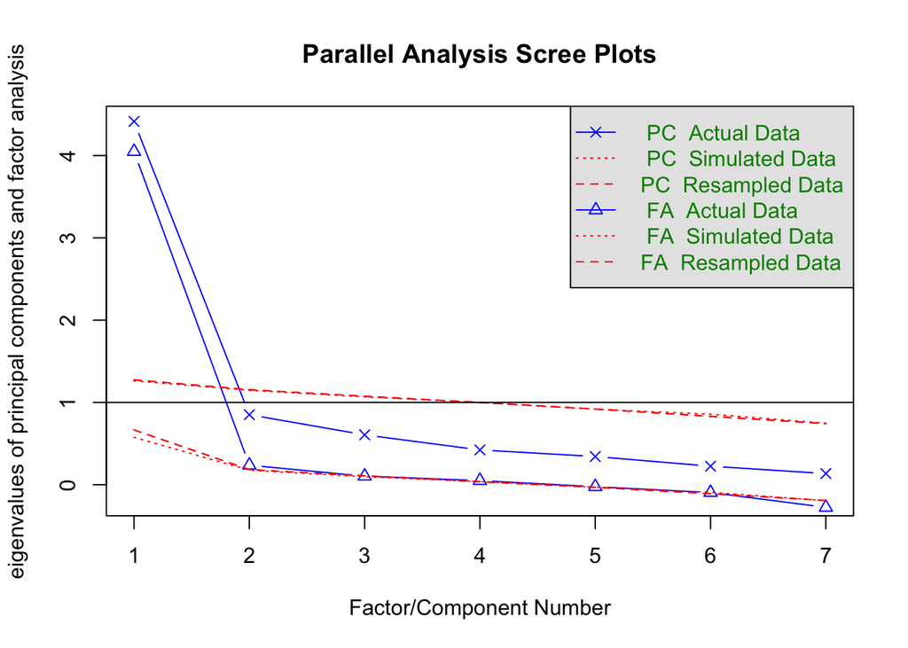

```
## Parallel analysis suggests that the number of factors =  2  and the number of components =  1
```

```r
fa.parallel(house_vars)
```

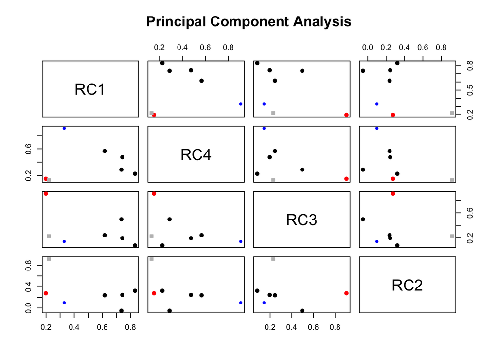

```r
fa.plot(fit.pc)
```

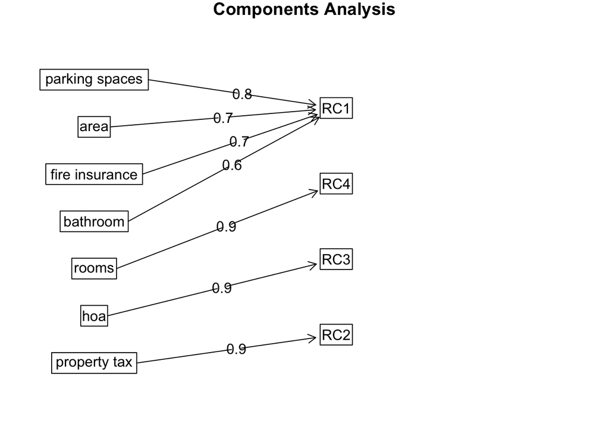

```r
fa.diagram(fit.pc)
```

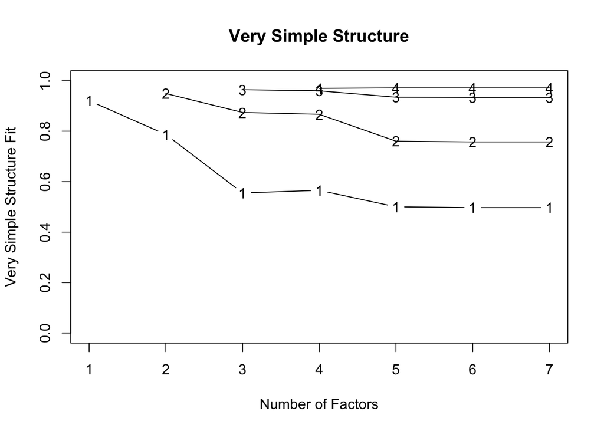

```
##
## Very Simple Structure
## Call: vss(x = house_vars)
## VSS complexity 1 achieves a maximimum of 0.92  with  1  factors
## VSS complexity 2 achieves a maximimum of 0.95  with  2  factors
##
## The Velicer MAP achieves a minimum of 0.05  with  1  factors
## BIC achieves a minimum of  7.67  with  3  factors
## Sample Size adjusted BIC achieves a minimum of  17.18  with  3  factors
##
## Statistics by number of factors
##   vss1 vss2   map dof   chisq    prob sqresid  fit RMSEA  BIC SABIC complex
## 1 0.92 0.00 0.053  14 8.6e+01 2.0e-12    1.66 0.92  0.16 12.0    56     1.0
## 2 0.79 0.95 0.102   8 5.3e+01 1.0e-08    1.06 0.95  0.17 10.8    36     1.4
## 3 0.56 0.87 0.179   3 2.4e+01 3.1e-05    0.74 0.96  0.19  7.7    17     1.7
## 4 0.57 0.87 0.306  -1 1.8e-01      NA    0.63 0.97    NA   NA    NA     1.8
## 5 0.50 0.76 0.425  -4 1.7e-10      NA    0.50 0.98    NA   NA    NA     2.1
## 6 0.50 0.76 1.000  -6 2.5e-11      NA    0.50 0.98    NA   NA    NA     2.1
## 7 0.50 0.76    NA  -7 2.5e-11      NA    0.50 0.98    NA   NA    NA     2.1
##    eChisq    SRMR eCRMS eBIC
## 1 3.1e+01 6.1e-02 0.074  -43
## 2 1.1e+01 3.6e-02 0.058  -32
## 3 3.4e+00 2.0e-02 0.053  -13
## 4 2.3e-02 1.6e-03    NA   NA
## 5 1.4e-11 4.1e-08    NA   NA
## 6 2.4e-12 1.7e-08    NA   NA
## 7 2.4e-12 1.7e-08    NA   NA
```

```r
vss(house_vars)
```

```r
fit.pc1 <- principal(house_vars, nfactors=2, rotate="varimax")
round(fit.pc$values, 3)
```

```
## [1] 4.415 0.851 0.606 0.423 0.343 0.226 0.136
```

## components_analysis

### Components Analysis

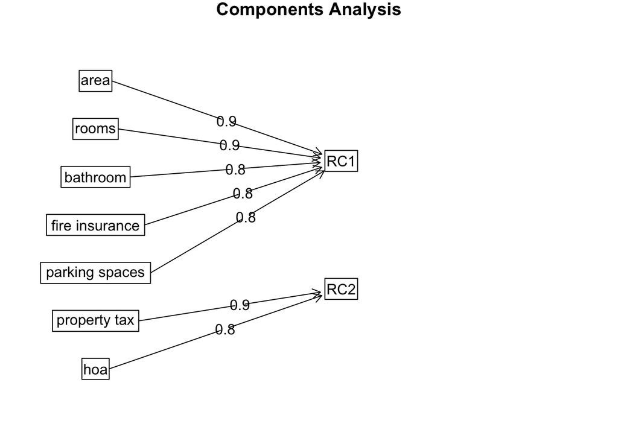

```r
fa.diagram(fit.pc1)
```

## variance

```r
corrm.emp <- cor(house_vars[-1])
corrm.emp
```

```
##                    rooms  bathroom parking spaces       hoa property tax
## rooms          1.0000000 0.7083450      0.5638594 0.3664647    0.3185592
## bathroom       0.7083450 1.0000000      0.7204068 0.5042408    0.4554111
## parking spaces 0.5638594 0.7204068      1.0000000 0.4270628    0.4716517
## hoa            0.3664647 0.5042408      0.4270628 1.0000000    0.4855746
## property tax   0.3185592 0.4554111      0.4716517 0.4855746    1.0000000
## fire insurance 0.5792533 0.6702586      0.6088245 0.5550327    0.3346348
##                fire insurance
## rooms               0.5792533
## bathroom            0.6702586
## parking spaces      0.6088245
## hoa                 0.5550327
## property tax        0.3346348
## fire insurance      1.0000000
```

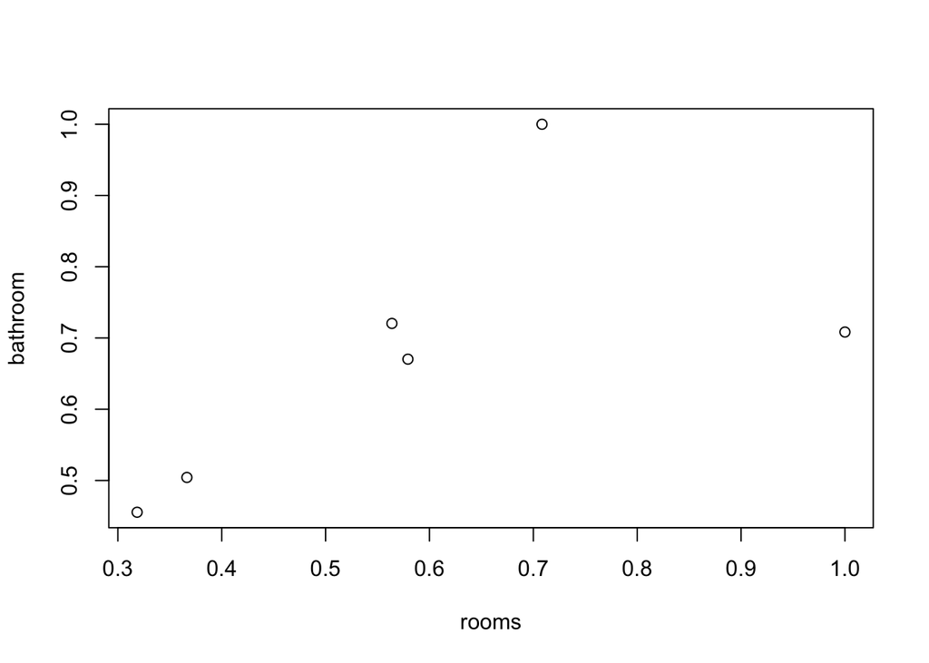

```r
plot(corrm.emp)
```

```r
house_vars_pca <- prcomp(house_vars[-1], scale=TRUE)
summary(house_vars_pca)
```

```
## Importance of components:
##                           PC1    PC2     PC3    PC4    PC5     PC6
## Standard deviation     1.9040 0.9096 0.77360 0.6462 0.5532 0.47458
## Proportion of Variance 0.6042 0.1379 0.09974 0.0696 0.0510 0.03754
## Cumulative Proportion  0.6042 0.7421 0.84186 0.9115 0.9625 1.00000
```

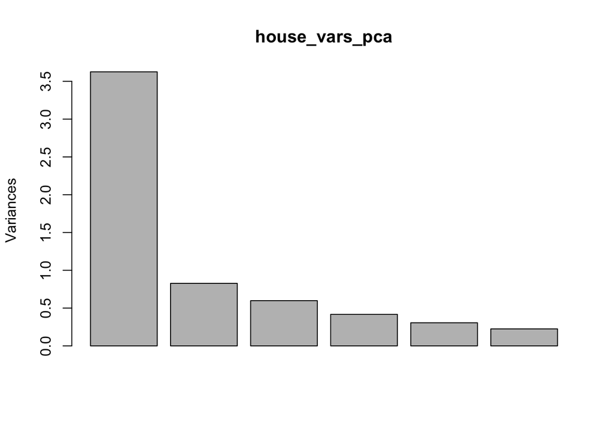

```r
plot(house_vars_pca)
```

## factors_columns

```r
(eigen_house_vars <- round(house_vars_pca$sdev^2,3))
```

```
## [1] 3.625 0.827 0.598 0.418 0.306 0.225
```

```r
names(eigen_house_vars) <- paste("PC",1:6,sep="")
sumlambdas <- sum(eigen_house_vars)
propvar <- round(eigen_house_vars/sumlambdas,2)
cumvar_house_vars <- cumsum(propvar)
matlambdas <- rbind(eigen_house_vars,propvar,cumvar_house_vars)
rownames(matlambdas) <- c("Eigenvalues","Prop. variance","Cum. prop. variance")
eigvec.emp <- house_vars_pca$rotation
pcafactors.emp <- eigvec.emp[,1:2]
unrot.fact.emp <- sweep(pcafactors.emp,MARGIN=2,house_vars_pca$sdev[1:2],`*`)
communalities.emp <- rowSums(unrot.fact.emp^2)
communalities.emp
```

```
##          rooms       bathroom parking spaces            hoa   property tax
##      0.7578867      0.8239901      0.6942779      0.6835603      0.7962199
## fire insurance
##      0.6967861
```

```r
rot.fact.emp <- varimax(unrot.fact.emp)
rot.fact.emp
```

```
## $loadings
##
## Loadings:
##                PC1    PC2
## rooms          -0.866
## bathroom       -0.844  0.335
## parking spaces -0.747  0.369
## hoa            -0.343  0.752
## property tax   -0.175  0.875
## fire insurance -0.774  0.312
##
##                  PC1   PC2
## SS loadings    2.767 1.686
## Proportion Var 0.461 0.281
## Cumulative Var 0.461 0.742
##
## $rotmat
##           [,1]       [,2]
## [1,] 0.8324983 -0.5540276
## [2,] 0.5540276  0.8324983
```

```r
fact.load.emp <- rot.fact.emp$loadings[1:6,1:2]
fact.load.emp
```

```
##                       PC1       PC2
## rooms          -0.8656407 0.0924822
## bathroom       -0.8437599 0.3347525
## parking spaces -0.7469370 0.3692736
## hoa            -0.3425851 0.7524598
## property tax   -0.1746465 0.8750534
## fire insurance -0.7742501 0.3119660
```

```r
scale.emp <- scale(house_vars[-1])
scale.emp
```

[output not shown]

[output cut: 397 more lines]

```r
as.matrix(scale.emp)%*%fact.load.emp%*%solve(t(fact.load.emp)%*%fact.load.emp)
```

```
##                PC1           PC2
##   [1,] -1.02101847  0.1380849672
##   [2,]  0.87780566  1.0788328277
##   [3,]  0.57532859 -0.4095601191
##   [4,]  1.09042847 -0.1711974262
##   [5,] -1.44057642 -1.0874339308
##   [6,] -0.93782839  0.7707497585
##   [7,]  1.07410649 -0.2913994903
##   [8,]  0.28520741  0.4317580903
##   [9,] -0.57203522 -0.3969285318
##  [10,] -0.77664555  0.5299969078
##  [11,]  0.37020663 -0.2201966280
##  [12,] -0.75003626  0.8322227233
##  [13,]  0.38333590 -0.3929895673
##  [14,]  1.13260938 -0.0475507340
```

[output cut: 186 more lines]